# Bank Personal Loan Modelling

# Distribution of ZIP Code with no Personal Loan

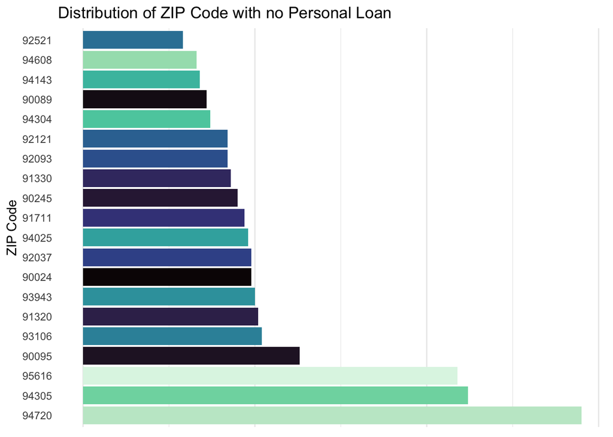

```r
df$ZIP_Code <- as.factor(df$ZIP_Code)

# subset data for Mortgage == 0
df_subset <- subset(df, Personal_Loan == 0)

# order ZIP Code by count of Mortgage == 0
zip_order <- as.character(names(sort(table(df_subset$ZIP_Code), decreasing = TRUE)))[1:20]

# plot count of ZIP Code
ggplot(df_subset, aes(y = ZIP_Code, fill = ZIP_Code)) +
  geom_bar() +
  scale_fill_viridis_d(option = "mako") +
  scale_y_discrete(limits = zip_order) +
  theme_minimal() +
  theme(legend.position = "none",
        axis.text.x = element_blank(),
        axis.title.x = element_blank(),
        axis.line.y = element_blank(),
        axis.ticks.y = element_blank(),
        panel.grid.major.y = element_blank(),
        panel.grid.minor.y = element_blank()) +
  labs(title = "Distribution of ZIP Code with no Personal Loan", style = list(fontSize='25px',
                                                                         fontWeight= 'bold'),
       y = "ZIP Code")
```

The rest of the Descriptive analytics can be on dasboard following link: “https://ad699.netlify.app/”

#Part 3.Building regression and classifier

```r
df <- df %>%
  filter(Experience>=0)
df2 <- df %>%
  select(Age,Experience,Income,Family,CCAvg,Education,Mortgage,
         Securities_Account,CD_Account,Personal_Loan)
```

Online is removed because its an unspecified variable.

```r
df$ZIP_Code <- as.numeric(df$ZIP_Code)
cor(df)
```

```
##                     ID_Customer           Age    Experience       Income
## ID_Customer         1.000000000 -0.0097943369 -0.0094055729 -0.017255228
## Age                -0.009794337  1.0000000000  0.9941014890 -0.058005788
## Experience         -0.009405573  0.9941014890  1.0000000000 -0.049244828
## Income             -0.017255228 -0.0580057884 -0.0492448284  1.000000000
## ZIP_Code            0.001980611 -0.0303859820 -0.0301130130 -0.026820677
## Family             -0.016382364 -0.0392786041 -0.0456099542 -0.155665764
## CCAvg              -0.025607184 -0.0508788729 -0.0489389617  0.646178154
## Education           0.021902227  0.0462218656  0.0182432552 -0.187992205
## Mortgage           -0.011171557 -0.0151839719 -0.0134592936  0.206920864
## Personal_Loan      -0.025123894 -0.0142035607 -0.0141208097  0.504227656
## Securities_Account -0.018960797  0.0004958185 -0.0004570698 -0.002327176
## CD_Account         -0.007084957  0.0032612003  0.0054504754  0.170170907
## Online             -0.001508087  0.0135424935  0.0135184842  0.014432567
## CreditCard          0.017293905  0.0074956879  0.0088760955 -0.004493256
##                         ZIP_Code       Family        CCAvg    Education
## ID_Customer         0.0019806113 -0.016382364 -0.025607184  0.021902227
## Age                -0.0303859820 -0.039278604 -0.050878873  0.046221866
## Experience         -0.0301130130 -0.045609954 -0.048938962  0.018243255
## Income             -0.0268206774 -0.155665764  0.646178154 -0.187992205
## ZIP_Code            1.0000000000  0.024633570 -0.010972918 -0.010510145
## Family              0.0246335703  1.000000000 -0.107230226  0.064032351
## CCAvg              -0.0109729177 -0.107230226  1.000000000 -0.133939348
## Education          -0.0105101451  0.064032351 -0.133939348  1.000000000
## Mortgage            0.0064930538 -0.020418837  0.109904537 -0.032558771
## Personal_Loan      -0.0007335735  0.063087978  0.369387930  0.138339036
## Securities_Account  0.0032386770  0.020155206  0.012476822 -0.007508034
## CD_Account          0.0215460184  0.015273754  0.137586572  0.014638931
## Online              0.0311028342  0.008465713 -0.003476440 -0.013932195
## CreditCard          0.0223712519  0.012905354 -0.007376833 -0.012604345
##                        Mortgage Personal_Loan Securities_Account   CD_Account
## ID_Customer        -0.011171557 -0.0251238943      -0.0189607971 -0.007084957
## Age                -0.015183972 -0.0142035607       0.0004958185  0.003261200
## Experience         -0.013459294 -0.0141208097      -0.0004570698  0.005450475
## Income              0.206920864  0.5042276560      -0.0023271758  0.170170907
## ZIP_Code            0.006493054 -0.0007335735       0.0032386770  0.021546018
## Family             -0.020418837  0.0630879776       0.0201552065  0.015273754
## CCAvg               0.109904537  0.3693879296       0.0124768215  0.137586572
## Education          -0.032558771  0.1383390364      -0.0075080343  0.014638931
## Mortgage            1.000000000  0.1423218419      -0.0037171431  0.089368528
## Personal_Loan       0.142321842  1.0000000000       0.0222158623  0.315769398
## Securities_Account -0.003717143  0.0222158623       1.0000000000  0.319055820
## CD_Account          0.089368528  0.3157693984       0.3190558203  1.000000000
## Online             -0.006754050  0.0061751844       0.0161014704  0.176767839
## CreditCard         -0.006909691  0.0027757292      -0.0170302693  0.280150625
##                          Online   CreditCard
## ID_Customer        -0.001508087  0.017293905
## Age                 0.013542493  0.007495688
## Experience          0.013518484  0.008876095
## Income              0.014432567 -0.004493256
## ZIP_Code            0.031102834  0.022371252
## Family              0.008465713  0.012905354
## CCAvg              -0.003476440 -0.007376833
## Education          -0.013932195 -0.012604345
## Mortgage           -0.006754050 -0.006909691
## Personal_Loan       0.006175184  0.002775729
## Securities_Account  0.016101470 -0.017030269
## CD_Account          0.176767839  0.280150625
## Online              1.000000000  0.008457430
## CreditCard          0.008457430  1.000000000
```

Correlation coefficients whose magnitude are between 0.7 and 1.0 indicate variables which can be considered highly correlated. Age and experience are also highly correlated because older people are normally have more working experience. So experience can be removed. Also Zipcode can be removed because its correlation with the personal loan is very low.

```r
df2 <- df2 %>%
  select(Age,Income,Family,CCAvg,Education,Mortgage,
         Securities_Account,CD_Account,Personal_Loan)
```

```r
set.seed(699)
df2 <- slice_sample(df2, prop =1)
train <- slice_head(df2, prop = 0.6)
valid <- slice_tail(df2, prop = 0.4)
```

# Muitiple Linear Regression Model

```r
mlr <- lm(data=train, formula=Personal_Loan ~.)
summary(mlr)
```

```
##
## Call:
## lm(formula = Personal_Loan ~ ., data = train)
##
## Residuals:
##      Min       1Q   Median       3Q      Max
## -0.68244 -0.14079 -0.03393  0.07058  1.03874
##
## Coefficients:
##                      Estimate Std. Error t value Pr(>|t|)
## (Intercept)        -4.085e-01  2.523e-02 -16.192  < 2e-16 ***
## Age                 3.078e-04  3.896e-04   0.790  0.42955
## Income              3.119e-03  1.301e-04  23.971  < 2e-16 ***
## Family              3.238e-02  3.870e-03   8.365  < 2e-16 ***
## CCAvg               1.061e-02  3.269e-03   3.244  0.00119 **
## Education           8.125e-02  5.264e-03  15.435  < 2e-16 ***
## Mortgage            4.913e-05  4.339e-05   1.132  0.25762
## Securities_Account -5.028e-02  1.534e-02  -3.277  0.00106 **
## CD_Account          2.871e-01  1.948e-02  14.737  < 2e-16 ***
## ---
## Signif. codes:  0 '***' 0.001 '**' 0.01 '*' 0.05 '.' 0.1 ' ' 1
##
## Residual standard error: 0.2382 on 2959 degrees of freedom
## Multiple R-squared:  0.3772, Adjusted R-squared:  0.3755
## F-statistic:   224 on 8 and 2959 DF,  p-value: < 2.2e-16
```

```r
mlr_backward <- step(mlr, direction = "backward")
```

```
## Start:  AIC=-8505.98
## Personal_Loan ~ Age + Income + Family + CCAvg + Education + Mortgage +
##     Securities_Account + CD_Account
##
##                      Df Sum of Sq    RSS     AIC
## - Age                 1     0.035 167.99 -8507.4
## - Mortgage            1     0.073 168.03 -8506.7
## <none>                            167.95 -8506.0
## - CCAvg               1     0.597 168.55 -8497.4
## - Securities_Account  1     0.610 168.56 -8497.2
## - Family              1     3.972 171.92 -8438.6
## - CD_Account          1    12.327 180.28 -8297.8
## - Education           1    13.522 181.47 -8278.2
## - Income              1    32.615 200.57 -7981.3
##
## Step:  AIC=-8507.36
## Personal_Loan ~ Income + Family + CCAvg + Education + Mortgage +
##     Securities_Account + CD_Account
##
##                      Df Sum of Sq    RSS     AIC
## - Mortgage            1     0.074 168.06 -8508.1
## <none>                            167.99 -8507.4
## - CCAvg               1     0.596 168.58 -8498.8
## - Securities_Account  1     0.615 168.60 -8498.5
## - Family              1     3.940 171.93 -8440.6
## - CD_Account          1    12.325 180.31 -8299.2
## - Education           1    13.576 181.56 -8278.7
## - Income              1    32.582 200.57 -7983.2
##
## Step:  AIC=-8508.05
## Personal_Loan ~ Income + Family + CCAvg + Education + Securities_Account +
##     CD_Account
##
##                      Df Sum of Sq    RSS     AIC
## <none>                            168.06 -8508.1
## - CCAvg               1     0.585 168.65 -8499.7
## - Securities_Account  1     0.621 168.68 -8499.1
## - Family              1     3.964 172.03 -8440.9
## - CD_Account          1    12.441 180.50 -8298.1
## - Education           1    13.579 181.64 -8279.4
## - Income              1    34.129 202.19 -7961.3
```

```r
summary(mlr_backward)
```

```
##
## Call:
## lm(formula = Personal_Loan ~ Income + Family + CCAvg + Education +
##     Securities_Account + CD_Account, data = train)
##
## Residuals:
##      Min       1Q   Median       3Q      Max
## -0.69216 -0.13948 -0.03475  0.07231  1.04383
##
## Coefficients:
##                     Estimate Std. Error t value Pr(>|t|)
## (Intercept)        -0.393040   0.017251 -22.784  < 2e-16 ***
## Income              0.003140   0.000128  24.521  < 2e-16 ***
## Family              0.032269   0.003861   8.358  < 2e-16 ***
## CCAvg               0.010494   0.003268   3.211  0.00134 **
## Education           0.081379   0.005261  15.467  < 2e-16 ***
## Securities_Account -0.050743   0.015339  -3.308  0.00095 ***
## CD_Account          0.288119   0.019461  14.805  < 2e-16 ***
## ---
## Signif. codes:  0 '***' 0.001 '**' 0.01 '*' 0.05 '.' 0.1 ' ' 1
##
## Residual standard error: 0.2382 on 2961 degrees of freedom
## Multiple R-squared:  0.3768, Adjusted R-squared:  0.3755
## F-statistic: 298.4 on 6 and 2961 DF,  p-value: < 2.2e-16
```

```r
pred.train <- predict(mlr_backward, train)
accuracy(pred.train, train$Personal_Loan)
```

```
##                     ME      RMSE       MAE MPE MAPE
## Test set -3.605954e-15 0.2379593 0.1642916 NaN  Inf
```

```r
pred.valid <- predict(mlr_backward, valid)
accuracy(pred.valid, valid$Personal_Loan)
```

```
##                   ME      RMSE       MAE MPE MAPE
## Test set -0.01100458 0.2250647 0.1552652 NaN  Inf
```

Errors (Smaller the better) ME: Mean error, error = acual - prediction MEA: mean absolute error MPE: mean percentage error MAPE: mean absolute precentage error RMSE: root mean square error sqrt(mean(error^2))

```r
sd(train$Personal_Loan)
```

```
## [1] 0.301483
```

# normalize the data

```r
train_norm <- scale(train[,1:8])
train_norm <- data.frame(train_norm)
train_norm <- cbind(train_norm,train$Personal_Loan)
colnames(train_norm)[ncol(train_norm)] <- "Personal_Loan"
```

```r
valid_norm <- scale(valid[,1:8])
valid_norm <- data.frame(valid_norm)
valid_norm <- cbind(valid_norm, valid$Personal_Loan)
colnames(valid_norm)[ncol(valid_norm)] <- "Personal_Loan"
```

# find the best value of K

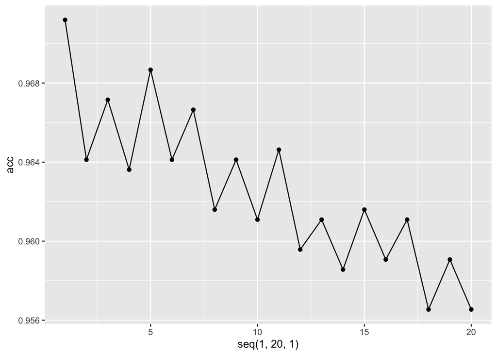

```r
library(FNN)
acc <- c()
for(k in seq(1, 20, 1)){
  m <- knn(train=train_norm[,1:8], test=valid_norm[,1:8], cl=train_norm[,9],
           k=k)
  acc <- c(acc, mean(valid_norm[,9]==m))
}

ggplot() + geom_point(aes(x=seq(1, 20, 1), y=acc)) +
  geom_line(aes(x=seq(1, 20, 1), y=acc))
```

k=1 is the best. Predict by 1 neighbors However, we will choose k=5 which also has very high accuracy (>96%) because using 5 neighbors as indicates of the prediction is more reliable than using only one neighbor.

```r
model_knn <- knn(train=train_norm[,1:8], test=valid_norm[,1:8], cl=train_norm[,9],k=5)
```

#Accuracy of KNN model

```r
sum(model_knn == valid_norm[,9]) / nrow(valid_norm)
```

```
## [1] 0.968671
```

96.8% accuracy

# Naive Bayes

```r
colnames(train)
```

```
## [1] "Age"                "Income"             "Family"
## [4] "CCAvg"              "Education"          "Mortgage"
## [7] "Securities_Account" "CD_Account"         "Personal_Loan"
```

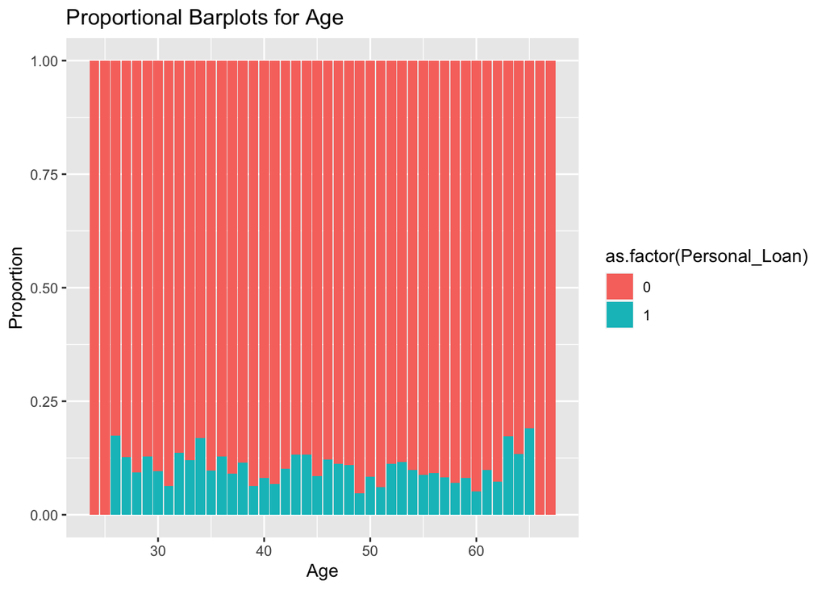

```r
ggplot(train) +
  geom_bar(aes(x = Age, fill = as.factor(Personal_Loan)), position = "fill") +
  labs(title = "Proportional Barplots for Age",
       x = "Age",
       y = "Proportion")
```

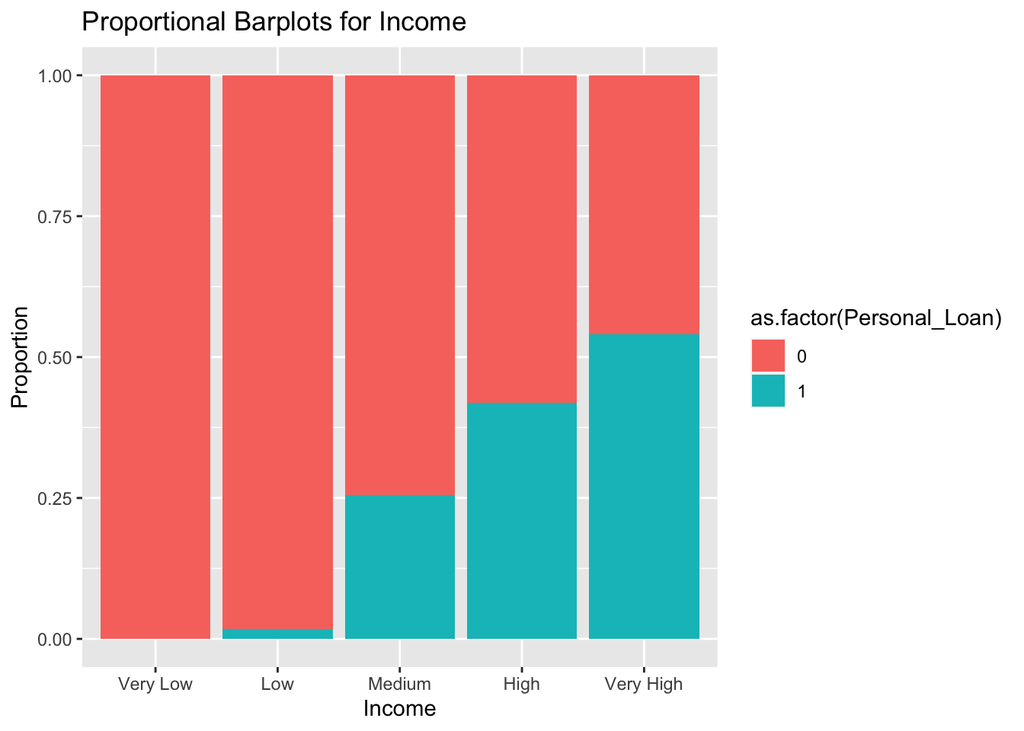

```r
train1 <- train %>% mutate(Income = cut(Income, breaks = 5, labels = c("Very Low", "Low", "Medium", "High", "Very High"), include.lowest = TRUE))


ggplot(train1) +
  geom_bar(aes(x = Income, fill = as.factor(Personal_Loan)), position = "fill") +
  labs(title = "Proportional Barplots for Income",
       x = "Income",
       y = "Proportion")
```

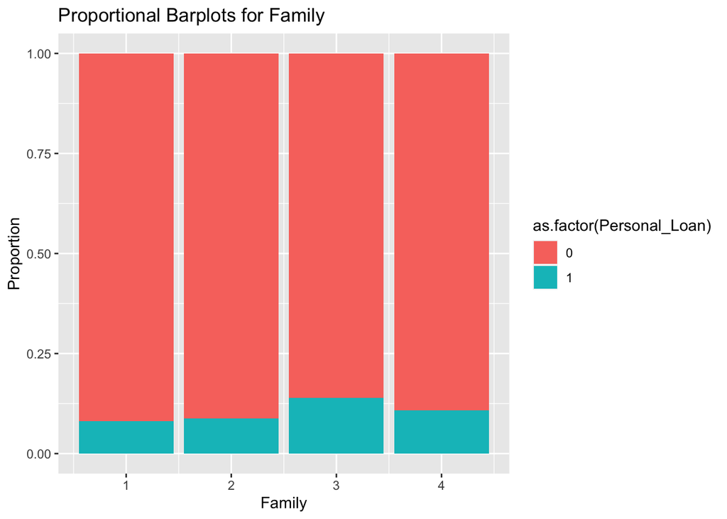

```r
ggplot(train1) +
  geom_bar(aes(x = Family, fill = as.factor(Personal_Loan)), position = "fill") +
  labs(title = "Proportional Barplots for Family",
       x = "Family",
       y = "Proportion")
```

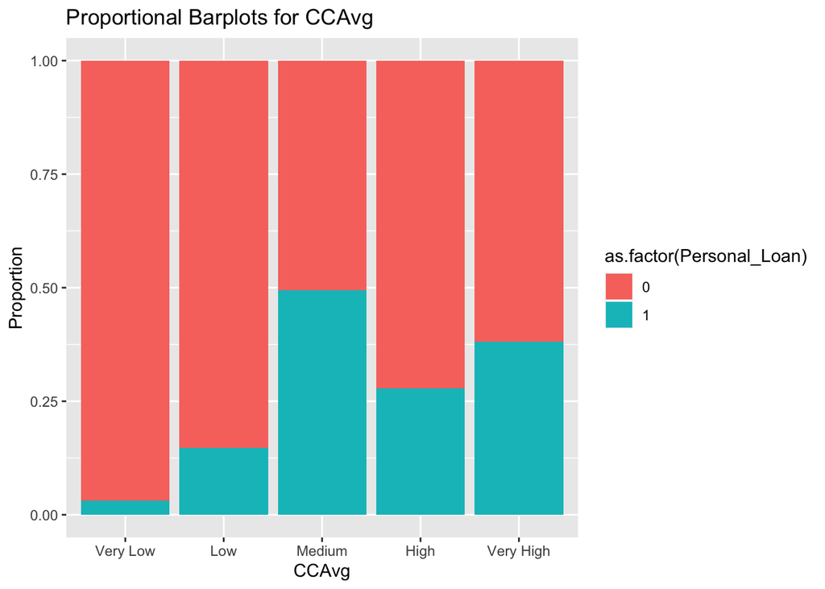

```r
train1 <- train %>% mutate(CCAvg = cut(CCAvg, breaks = 5, labels = c("Very Low", "Low", "Medium", "High", "Very High"), include.lowest = TRUE))


ggplot(train1) +
  geom_bar(aes(x = CCAvg, fill = as.factor(Personal_Loan)), position = "fill") +
  labs(title = "Proportional Barplots for CCAvg",
       x = "CCAvg",
       y = "Proportion")
```

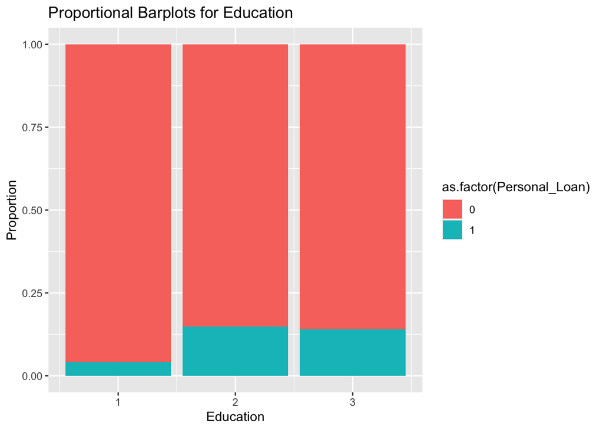

```r
ggplot(train1) +
  geom_bar(aes(x = Education, fill = as.factor(Personal_Loan)), position = "fill") +
  labs(title = "Proportional Barplots for Education",
       x = "Education",
       y = "Proportion")
```

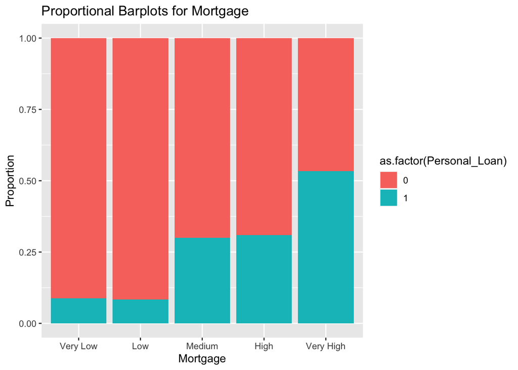

```r
train1 <- train %>% mutate(Mortgage = cut(Mortgage, breaks = 5, labels = c("Very Low", "Low", "Medium", "High", "Very High"), include.lowest = TRUE))


ggplot(train1) +
  geom_bar(aes(x = Mortgage, fill = as.factor(Personal_Loan)), position = "fill") +
  labs(title = "Proportional Barplots for Mortgage",
       x = "Mortgage",
       y = "Proportion")
```